# Reproducibility

Principles and Practice

Author

Affiliation

Daniela Palleschi

Humboldt-Universität zu Berlin

Published

April 30, 2024

# Learning Objectives

Today we will learn about…

- reproducibility rates in linguistics
- FAIR principles
- concepts for building a reproducible workflow

# Reproducibility

- generating the same results with the same data and analysis scripts
  - seems obvious, but requires organisation and forethought
- bare minimum: share the code and the data (Laurinavichyute et al., 2022)
- rates of reproducibility vary across fields (Bochynska et al., 2023)
  - open access: 25-65%
  - data and analyses sharing: 11-33%
  - pre-registrations: 0-3%
- what constitutes “reproducibility”?

## What should (ideally) be shared?

- materials
  - protocols
  - stimuli
  - experiment set-up
- documentation
  - README
  - metadata
- data
  - raw
    - e.g., text files, audio, video, or images
  - processed
- analysis code
  - pre-processing
  - analyses
- materials are helpful for replication
  - but also for inspection of e.g., design
- data and code are necessary for reproducibility
  - along with proper documentation of software used

## Reproducibility rates in linguistic research

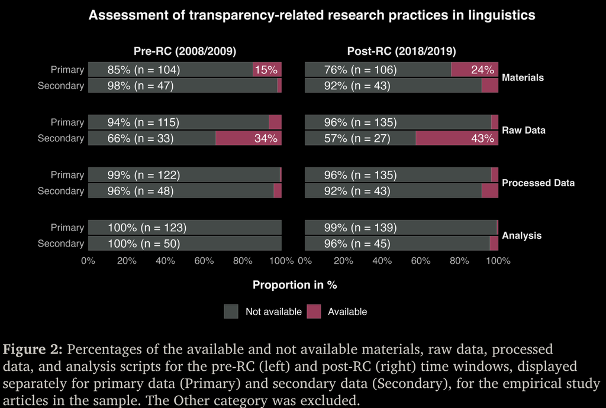

Figure 1: Source: Bochynska et al. (2023), p. 11 (all rights reserved)

- meta-analysis of 519 randomly sampled articles from various linguistic journales
  - pre- and post-reproducibility crisis (2008/9, 2018/19) (Bochynska et al., 2023)
  - differentiated between primary (collected for study) and secondary (pre-existing) data
- reported a post-RC increase in shared materials, data, and analyses
  - but still low rates of each
- higher rates of secondary data sharing, presumably due to publicly available corpora
- data shared more often than analyses, pre- and post-RC

## Journal of Memory and Language

- meta-analysis of articles from JML (Laurinavichyute et al., 2022)
  - before and after an Open Science Policy was introduced in 2019

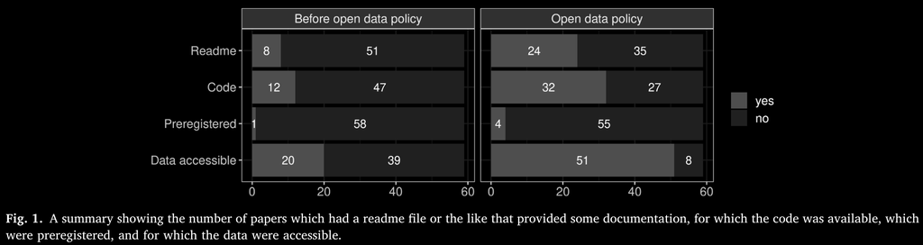

Figure 2: Source: Laurinavichyute et al. (2022), p. 5 (all rights reserved)

- code and data availability improved
- but reproducibility rate ranged from 34-56%, depending on criteria
- higher rates compared to field-wide meta-analysis (Bochynska et al., 2023)

# FAIR principles

- guidelines for sharing digital resources
- refers broadly to data, but we’ll consider it in terms of analyses

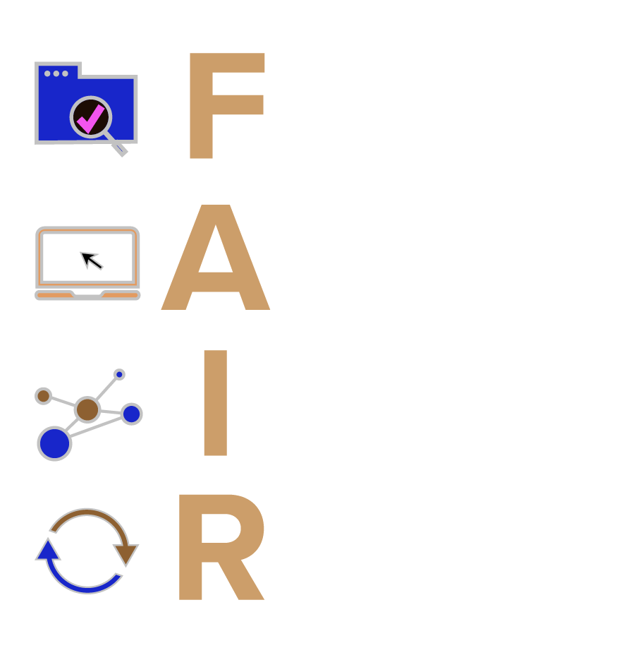

Figure 3: Source: [National Library of Medicine](https://www.nlm.nih.gov/oet/ed/cde/tutorial/02-300.html) (all rights reserved)

- findable and accesssible refer to where materials are stored
  - in *findable* repositories
  - that are *accessible*, i.e., do not require an account
- interoperable and reusable emphasise the format of data (and code)
  - the importance of future use
  - and use beyond your precise computational environment
- a great way to test the FAIR principles
  - code review!
  - i.e., have a colleague try to access your data/run your code
    - either via an online repository
    - or send them your project folder

## Findable

- refers to data and supplementary materials
- materials should have a “persistant identifier”
  - e.g., Digital Object Identifier (DOI) for scholarly articles
- a digital, long-term storage of data
  - *not* on a personal or professional website
  - GitHub files don’t typically have sufficient metadata
  - ideally: OSF, Zenodo or some other repository
- in recent papers, an OSF link is typically provided
- also: *discoverable*
  - e.g., in data-specific search engines (Google’s Dataset search)

## Accessible

- data (and code) should be
  - machine- and human-readable
  - available on a trusted repository, e.g., the OSF
  - Open Access
    - not behind a paywall
    - nor require a login

## Interoperable

- data (and code) should
  - not dependent on an operating system
  - nor entirely on software/package versions
- easiest work around:
  - document your software versions
  - this doesn’t automatically facilitate interoperability
  - but may help pinpoint where problems are coming from

## Reusable

- data (and code) should
  - be reusable for future research
- data format should be generic
  - i.e., not tied to a specific program
  - for tabular data, I recommend `.csv` format
- we can swap with ‘reproducible’ in the context of analyses

[figure not shown]

## Task: finding data

Go to datasetsearch.research.google.com/

- do a search for data related to a topic of interest to you
- what type of information does the search provide?
- what type of links?
- do you find analysis code, or just data?
- do the same search at [osf.io](https://osf.io/)
- and at zenodo.org/
  - are there the same amount of hits?

# Data and code availability

- “data available upon (reasonable) request”
  - generally not true
- data was not available in 68% of the most cited psychology studies (2006-2016) (Hardwicke & Ioannidis, 2018)
  - a further 18% were available with restrictions
  - only 11% available without restriction
- data alone is not sufficient
  - ‘Data Analysis’ sections are rarely exhaustive/unambiguous
  - very difficult to re-create analyses without code
  - e.g., is data trimming explicitly defined?
    - this will even affect descriptive statistics

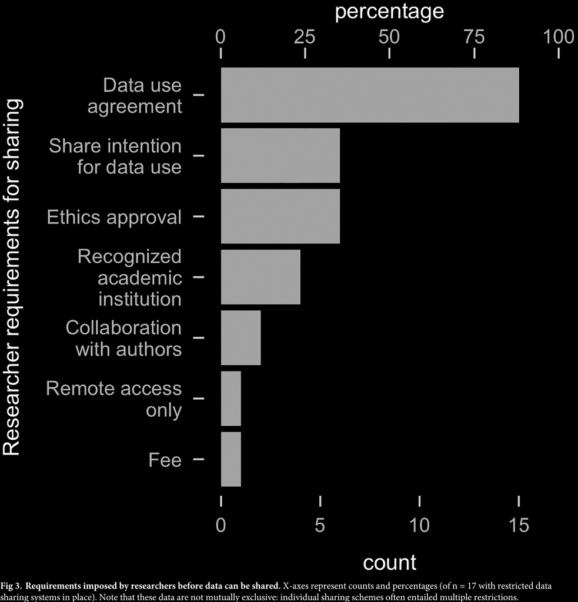

Figure 4: Source: Hardwicke & Ioannidis (2018), p. 6 (all rights reserved)

## Data and code $\neq$ Reproducibility

- even including code does not guarantee reproducibility
- access to data and code do not mean analyses are reproducible
- what can go wrong? Examples from Laurinavichyute et al. (2022)
1. Data problems
   - inaccessible data
   - incomplete data (e.g., 2/3 experiments)
2. Code problems
   - incomplete code
   - error messages
   - code rot: outdated syntax or environment
   - proprietary software
3. Documentation problems
   - data difficult to interpret
   - no README file/data dictionary
   - unclear folder/file/variable naming convention
   - manuscript contradicts code
4. Unclear terms of use
   - no licence specification

## Share the code, not just the data

- Why?
  - key details are often missing from ‘Methods’ sections
- suggestions for researchers from Laurinavichyute et al. (2022)
1. Share data in usable form
   - with pre-processing code
2. Use publicly accessible repositories
   - e.g., OSF
3. Use non-proprietary data formats
   - e.g., not `.xls` files (Excel)
4. Provide documentation
   - e.g., README, data dictionaries
5. Share code *and* data
   - they estimate a 38% increase in reproducibility
6. Teach data management and computing skills
   - that’s what this course is for!

# Building a reproducible workflow

- there are different levels of reproducibility
  - the *bare minimum* is sharing the code and data
  - *and* including session information:
    - which operating system was used
    - which software/package versions were used
- going bigger:
  - project-oriented workflow
  - project-specific filepaths
  - contained in a single project folder
- we will be using RProjects to achieve this

## Project management

- folder structure
- project-relative file paths
- appropriate documentation
  - e.g., README
- it’s great to map out your project structure early on
  - but it will grow as you go along
  - reproducible principles facilitate adapting as it grows

## Literate programming

> Instead of imagining that our main task is to instruct a *computer* what to do, let us concentrate rather on explaining to *human beings* what we want a computer to do.

— Knuth (1984), p. 97

- originally used to refer to writing programs
- but also applies to analysis code
  - especially if we’re aiming for reproducibility
- main concepts:
  - code is linear (this pre-dates Knuth, 1984)
  - informative but concise commenting
- main benefits:
  - facilitates maintenance
  - helpful for future-you, collaborators, etc.

## Documentation

- metadata
  - project README
  - codebook/data dictionary
- README should contain
  - a project description
  - relevant links
  - description of folder structure
- can be updated as the project develops
- README.md files in GitHub/Lab are automatically used as a project description
  - `.md` is a plaintext document
  - uses markdown syntax

## Version control

- git: local tracking
- useful for the analysis and writing phases
  - but can be tricky for collaboration
- GitHub/GitLab: remote tracking
  - store your changes to your local git repository
  - then push them to your remote repository
- safe guards against local hardware/software issues
  - lost or damaged computer or local files
- and allows for collaboration or sharing

## Persistant (public) storage

- GitHub/Lab are sub-optimal
  - developer-focused
  - typically lack thorough documentation/metadata
  - not very user-friendly for non-users
- OSF, Zenodo
  - Open Science-focused
  - can be linked to a GitHub/Lab repository
  - facilitate thorough documentation
  - user-friendly

## Writing

- dynamic reports with Markdown syntax
  - e.g., Rmarkdown, Quarto
  - integration of data, code, and prose
    - facilitates cross-referencing within document
    - integration of citation management tools
    - supports LaTeX syntax for example sentences and tables
- `papaja` package for APA-formatted Rmarkdown documents
- challenge: collaboration
  - not all collaborators know these tools
  - track changes not currently possible

# Setting up a project

- next week: hands-on
- required installations/recent versions of:
  - R
    - version `4.4.0`, “Puppy Cup”
    - check current version with `R.version`
    - download/update: https://cran.r-project.org/bin/macosx/
  - RStudio
    - version `2023.12.1.402`, “Ocean Storm”
    - Help > Check for updates
    - new install: https://posit.co/download/rstudio-desktop/

# Learning objectives 🏁

Today we learned…

- reproducibility rates in linguistics ✅
- FAIR principles ✅
- concepts for building a reproducible workflow ✅

# References

Bochynska, A., Keeble, L., Halfacre, C., Casillas, J. V., Champagne, I.-A., Chen, K., Röthlisberger, M., Buchanan, E. M., & Roettger, T. B. (2023). Reproducible research practices and transparency across linguistics. *Glossa Psycholinguistics*, *2*(1). https://doi.org/10.5070/G6011239

Corker, K. S. (2022). An Open Science Workflow for More Credible, Rigorous Research. In M. J. Prinstein (Ed.), *The Portable Mentor* (3rd ed., pp. 197–216). Cambridge University Press. https://doi.org/10.1017/9781108903264.012

Hardwicke, T. E., & Ioannidis, J. P. A. (2018). Populating the Data Ark: An attempt to retrieve, preserve, and liberate data from the most highly-cited psychology and psychiatry articles. *PLOS ONE*, *13*(8), e0201856. https://doi.org/10.1371/journal.pone.0201856

Knuth, D. (1984). Literate programming. *The Computer Journal*, *27*(2), 97–111.

Laurinavichyute, A., Yadav, H., & Vasishth, S. (2022). Share the code, not just the data: A case study of the reproducibility of articles published in the Journal of Memory and Language under the open data policy. *Journal of Memory and Language*, *125*, 12.